# Data 605 Discussion - Week 11

William Jasmine

2023-04-25

```r
library(tidyverse)
library(lmtest)
```

# Assignment Description

Using R, build a regression model for data that interests you. Conduct residual analysis. Was the linear model appropriate? Why or why not?

# Import, Clean Data

The data I will be using come from R’s `CO2` dataset, which records the carbon dioxide ($CO_2$) “uptake of six plants from Quebec and six plants from Mississippi measured at several levels of ambient $CO_2$ concentration. Half the plants of each type were chilled overnight before the experiment was conducted.” A summary of the data is provided below:

```r
data(CO2)
summary(CO2)
```

```
##      Plant             Type         Treatment       conc          uptake
##  Qn1    : 7   Quebec     :42   nonchilled:42   Min.   :  95   Min.   : 7.70
##  Qn2    : 7   Mississippi:42   chilled   :42   1st Qu.: 175   1st Qu.:17.90
##  Qn3    : 7                                    Median : 350   Median :28.30
##  Qc1    : 7                                    Mean   : 435   Mean   :27.21
##  Qc3    : 7                                    3rd Qu.: 675   3rd Qu.:37.12
##  Qc2    : 7                                    Max.   :1000   Max.   :45.50
##  (Other):42
```

To limit our regression model’s independent variables to two, the cell below filters the data to only include rows where `type=="Quebec"`:

```r
CO2 <- CO2 %>%
  filter(Type == 'Quebec')
```

# Build, Summarize Model

We can now build and summarize a linear regression model using `uptake` as the dependent variable, and `treatment` and `conc` as the independent variables:

```r
lin_reg <- lm(uptake ~ conc + Treatment, data=CO2)
summary(lin_reg)
```

```
##
## Call:
## lm(formula = uptake ~ conc + Treatment, data = CO2)
##
## Residuals:
##      Min       1Q   Median       3Q      Max
## -14.6052  -3.2628   0.7975   4.6594  10.6174
##
## Coefficients:
##                  Estimate Std. Error t value Pr(>|t|)
## (Intercept)      25.29351    2.12484  11.904 1.47e-14 ***
## conc              0.02308    0.00353   6.538 9.29e-08 ***
## Treatmentchilled -3.58095    2.07689  -1.724   0.0926 .
## ---
## Signif. codes:  0 '***' 0.001 '**' 0.01 '*' 0.05 '.' 0.1 ' ' 1
##
## Residual standard error: 6.73 on 39 degrees of freedom
## Multiple R-squared:  0.5396, Adjusted R-squared:  0.516
## F-statistic: 22.86 on 2 and 39 DF,  p-value: 2.694e-07
```

# Check Assumptions

The assumptions of linear regression are listed below:

1. *Linear relationship:* There exists a linear relationship between the independent variable, $x$, and the dependent variable, $y$.
2. *Normality:* The residuals of the model are normally distributed.
3. *Homoscedasticity:* The residuals have constant variance at every level of $x$.
4. *Independence*: The residuals are independent. In particular, there is no correlation between consecutive residuals in time series data.

## Linear Relationship

The below code plots the data against the model’s fitted lines for both chilled and non-chilled plants:

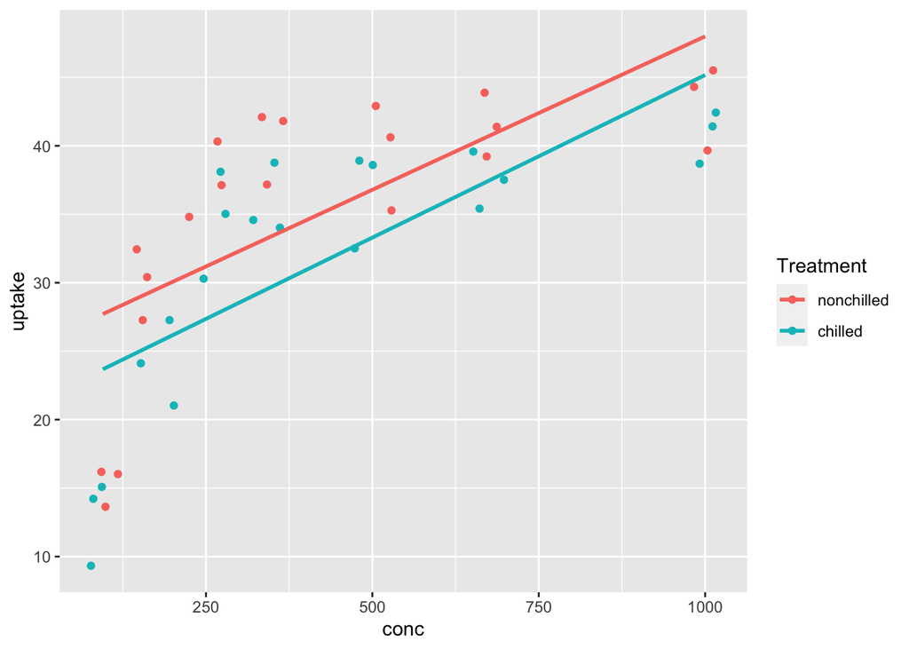

```r
ggplot(data = CO2, aes(x = conc, y = uptake, color = Treatment)) +
  geom_jitter() +
  geom_smooth(method = "lm", formula = y ~ x, se = FALSE)
```

## Normality

The code below plots a histogram of the residual lengths.

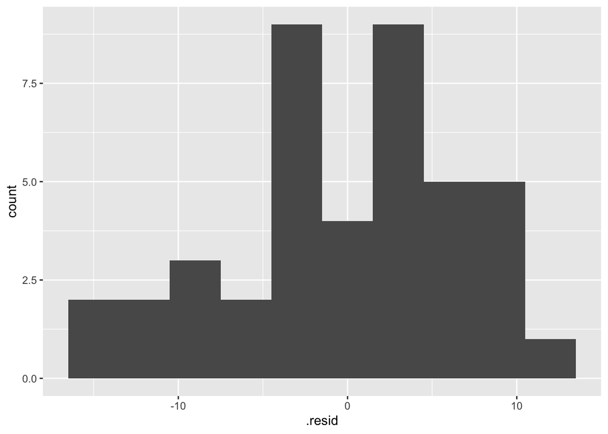

```r
ggplot(lin_reg, aes(x = .resid)) +
  geom_histogram(binwidth = 3)
```

The residuals do appear to be somewhat normally distributed. We can confirm this statistically via a Shapiro-Wilk hypothesis test on the lengths of the residuals:

```r
shapiro.test(lin_reg$residuals)
```

```
##
##  Shapiro-Wilk normality test
##
## data:  lin_reg$residuals
## W = 0.95857, p-value = 0.1313
```

## Homoscedasticity

The code creates a plot of the residuals as a function of the fitted values:

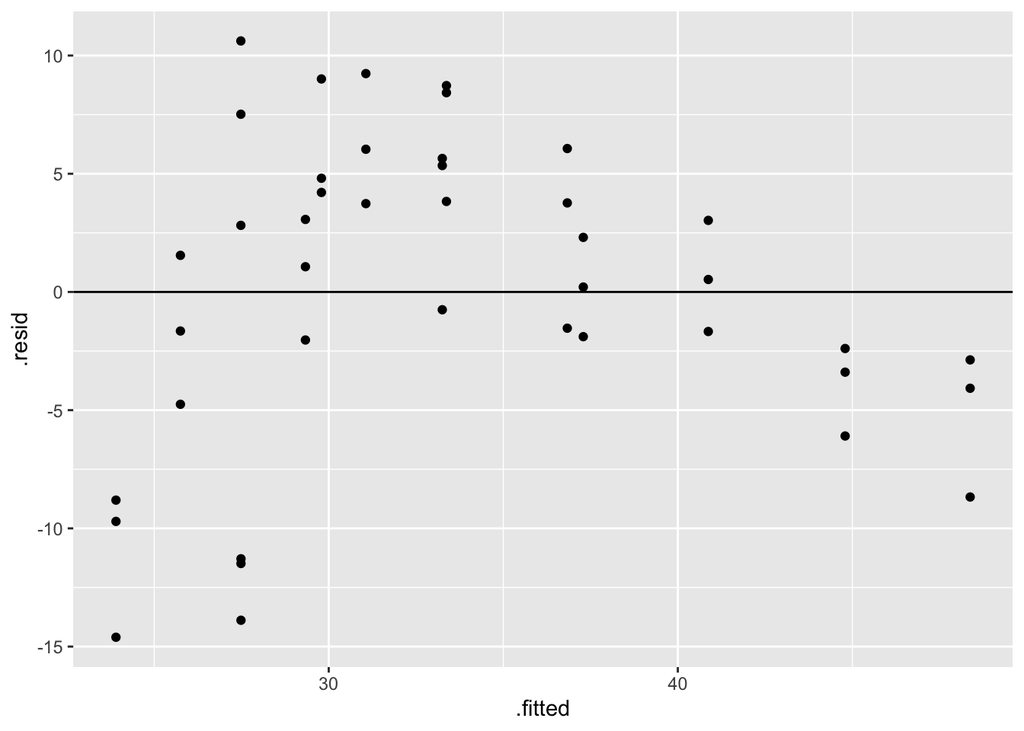

```r
ggplot(lin_reg, aes(x = .fitted, y = .resid)) +
  geom_point() +
  geom_hline(yintercept = 0)
```

This plot shows that the spread (variance) of the residual lengths is do not appear equal for all fitted values of `uptake`, in other words the data does not appear to be homoscedastic. We can confirm this via a Breusch-Pagan test:

```r
bptest(lin_reg)
```

```
##
##  studentized Breusch-Pagan test
##
## data:  lin_reg
## BP = 8.0554, df = 2, p-value = 0.01781
```

Indeed, the result of the test confirms that the data is not homoscedastic.

## Independence

Based off the above residual plot above, we can however confirm that there is not a strong correlation between the residuals and fitted values. This is further evidenced by the fact that the correlation coefficient between the two is very close to 0:

```r
cor(lin_reg$residuals, lin_reg$fitted.values)
```

```
## [1] 2.671187e-16
```

# Conclusion

Based off the analysis above we have confirmed that results of the `lin_reg` looked promising, residual analysis revealed that it does not satisfy the homoscedasticity condition. As such, it is not a valid model to be used in practice. Based off the appearance of the scatter plot data, a logarithmic function might be better suited as a model in this case.